# Comparing Greenland, Delta, and Monte Carlo Methods for PAF Confidence Intervals

## Introduction: What is the Population-Attributable Fraction?

The Population-Attributable Fraction (\(PAF\)) measures the proportion of disease cases in a population that can be attributed to an exposure.

- \(RR\) - Relative Risk
- \(P_e\) - proportion of the population exposed
- \(PAF\) Formula: \[ PAF = \frac{P_e(RR-1)}{P_e(RR-1)+1} \]

(Khosravi et al., 2021)

## Why PAF Confidence Intervals Matter

- Public health decisions depend on uncertainty estimates (CIs)
- However, PAF is bounded between 0 and 1, and many common CI methods:
  - Produce negative lower bounds, or
  - Upper bounds > 1, which are not interpretable.

**Goal:** Determine which CI method behaves best under realistic conditions.

## CI Methods Compared

**Based on:** *A Comparison of Green, Delta, and Monte Carlo Methods to Select an Optimal Approach for Calculating the 95% Confidence Interval of the Population-Attributable Fraction.* by Lee et al. (2024)

- Delta Method
  - Taylor-series linear approximation
  - Fast but struggles with nonlinear functions
- Greenland Method
  - Adjusts for exposure odds
  - More stable than Delta but still approximation-based
- Monte Carlo Method
  - Simulates many possible PAF values
  - Best reflects distribution shape
  - Naturally respects boundaries

(Lee et al., 2024)

## How the Simulation Works

- Simulate:
  - \(RR\)* from a log-normal distribution
  - \(P_e\)* from a binomial distribution
- Compute PAF using formula
- Generate 95% CI using Delta, Greenland, and Monte Carlo Methods

## How the Simulation Works (cont.)

- Repeat 500 times
- Compare:
  - \(PAF\) estimates
  - CI width
  - Coverage Probability
  - How often CIs leave our “valid range” of [0,1]

## Scenario A (Weak Association & Small PAF)

- Sample Size : 1,000
- \(P_e\): 0.10
- \(RR\) : 1.2
- True \(PAF\) : 0.0196
- Number of Simulations : 500

Scenario A: PAF estimates and 95% CIs.

| method | PAF | lower | upper |
| --- | --- | --- | --- |
| Delta | 0.01961 | 0.00406 | 0.03515 |
| Greenland | 0.01961 | 0.00387 | 0.03510 |
| Monte Carlo | 0.01955 | 0.00536 | 0.03655 |

Scenario A: Coverage and mean CI width.

| method | cover | width |
| --- | --- | --- |
| Delta | 0.956 | 0.03132 |
| Greenland | 0.956 | 0.03145 |
| Monte Carlo | 0.952 | 0.03149 |

Scenario A: Proportion of CIs outside the [0,1] interval

| method | prob_outside_01 |
| --- | --- |
| Delta | 0.262 |
| Greenland | 0.266 |
| Monte Carlo | 0.216 |

## Interpretation: Scenario A

**Key Takeaways**

- All methods gave very similar correct \(PAF\) estimates
- CI widths and coverage probabilities are nearly identical across methods
- Monte Carlo produced slightly wider CIs, but also the fewest invalid CIs
- Delta and Greenland methods are slightly more precise but have a greater tendency to dip below zero when the true \(PAF\) is very small

**Conclusion:**

For small \(PAF\)s, Monte Carlo is the most reliable of the three

## Scenario B (Strong Association & Large PAF)

- Sample Size : 100,000
- \(P_e\): 0.10
- \(RR\) : 5.0
- True \(PAF\) : 0.2857
- Number of Simulations : 500

Scenario B: PAF estimates and 95% CIs.

| method | PAF | lower | upper |
| --- | --- | --- | --- |
| Delta | 0.28571 | 0.25204 | 0.31939 |
| Greenland | 0.28571 | 0.25123 | 0.31861 |
| Monte Carlo | 0.28577 | 0.25265 | 0.31994 |

Scenario B: Coverage and mean CI width.

| method | cover | width |
| --- | --- | --- |
| Delta | 0.954 | 0.03128 |
| Greenland | 0.952 | 0.03142 |
| Monte Carlo | 0.944 | 0.03138 |

Scenario B: Proportion of CIs outside the [0,1] range

| method | prob_outside_01 |
| --- | --- |
| Delta | 0.256 |
| Greenland | 0.270 |
| Monte Carlo | 0.208 |

## Interpretation: Scenario B

**Key Takeaways** - All methods accurately estimate the true \(PAF\) and produce similarly sized confidence intervals

- Monte Carlo shows slightly worse coverage here than in Scenario A but still performs well overall
- Delta and Greenland maintain strong coverage but at the cost of more CI values falling outside [0,1].

**Conclusion:**

As in Scenario A, Monte Carlo is consistently the most boundary-respecting method, even when the true \(PAF\) is large

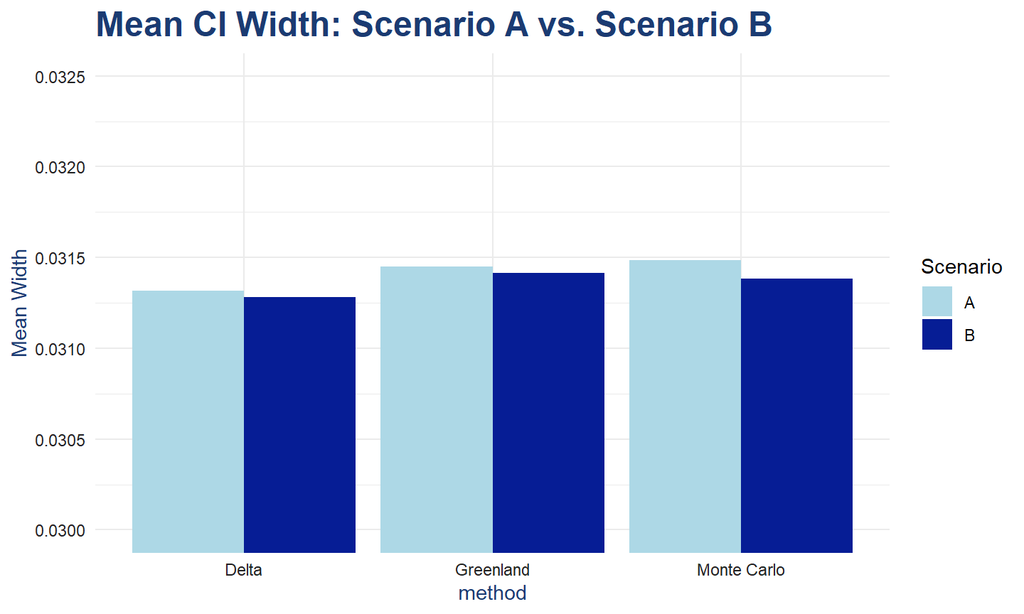

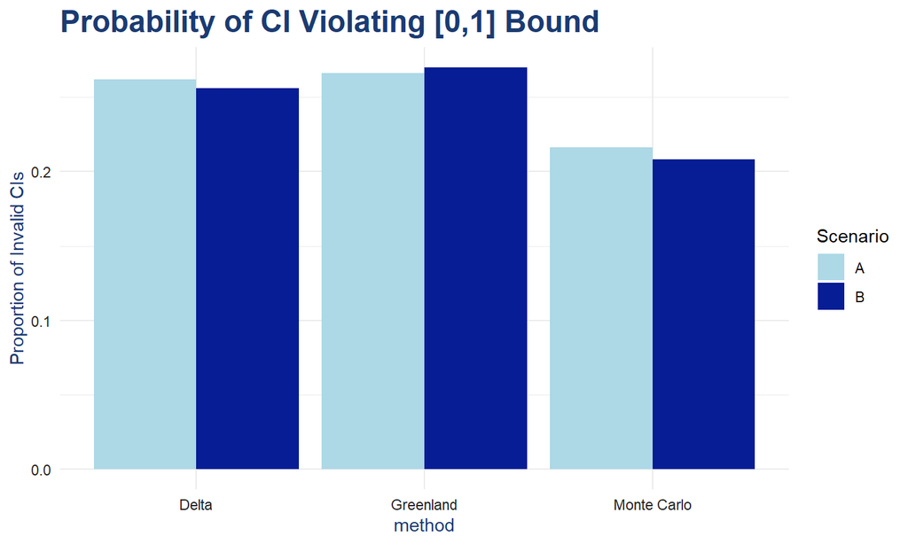

## Why Monte Carlo Performs Better

**Strengths**

- Handles non-linearity of PAF formula
- Produces naturally bounded estimates
- Captures skewed uncertainty better than linear approximations

**Weaknesses**

- Requires more computation

**Summary**

Monte Carlo avoids the main problems seen in Delta/Greenland methods.

## When Should Each Method Be Used?

| Method | Strengths | Weaknesses | Best Use Case |
| --- | --- | --- | --- |
| **Delta** | Fast, simple | Can go below 0 | Large samples, moderate RR and mid-range PAF |
| **Greenland** | Adjusted for exposure odds | Still boundary issues | Small Pe, moderate RR |
| **Monte Carlo** | Most accurate, best boundaries | More computation | PAF near 0 or 1, strong RR, boundary-sensitive |

## Practical Implications for Epidemiology

- Avoid reporting negative CIs or CIs >1
- Use Monte Carlo when:
  - \(PAF\) is very small or very large
  - \(RR\) is large
  - Boundary validity is important

## Limitations

- Only two scenarios replicated
- Monte Carlo used 10,000 samples — could explore smaller sizes
- \(PAF\) is only valid if RR is a causal effect -\(RR\) cannot be confounded or biased

(Greenland, 2015)

## Final Takeaway

**Monte Carlo is the most reliable and interpretable method for constructing confidence intervals for the Population-Attributable Fraction, especially when:**

- PAF is small
- RR is large
- Staying within the logical boundary is necessary

## References

Greenland, S. (2015). Concepts and pitfalls in measuring and interpreting attributable fractions, prevented fractions, and causation probabilities. Annals of Epidemiology, 25(3), 155–161. PubMed. https://doi.org/10.1016/j.annepidem.2014.11.005

Khosravi, A., Nazemipour, M., Shinozaki, T., & Mansournia, M. A. (2021). Population attributable fraction in textbooks: Time to revise. Global Epidemiology, 3(PubMed). https://doi.org/10.1016/j.gloepi.2021.100062

Lee, S., Moon, S., Kim, K., Sung, S., Hong, Y., Lim, W., & Park, S. K. (2024). A Comparison of Green, Delta, and Monte Carlo Methods to Select an Optimal Approach for Calculating the 95% Confidence Interval of the Population-attributable Fraction: Guidance for Epidemiological Research. Journal of Preventive Medicine and Public Health = Yebang Uihakhoe Chi, 57(5), 499–507. PubMed. https://doi.org/10.3961/jpmph.24.272